# Pittsburgh Crime Map

Chen,Yuying,Lilik

March 29, 2017

# Cleaning Function

Load data

```r
dat<- read.csv("ArrestData.csv")
```

Load library

```r
library(dplyr)
```

```r
library(ggplot2)
```

Filt the dataframe and get the first type of offense

```r
easierdat<-function(x,frame){
  offense<-strsplit(as.character(x),"/")
  mainoffense<-sapply(offense,"[[",1)
  First_Offenses<-mainoffense
  matches<-gregexpr("[0-9]+",x)
  FullCode<-regmatches(x,matches)
  FullCode<-sapply(FullCode,"[[",1)
  frame<-cbind(frame,FullCode,stringsAsFactors=F)
  FullCode[which(nchar(FullCode) == 2)]<-"13(a)"
  FullCode[which(nchar(FullCode) == 4)]<-substr( FullCode[which(nchar(FullCode) == 4)],1,2)
  FullCode[which(nchar( FullCode) == 3)]<-substr( FullCode[which(nchar( FullCode) == 3)],1,1)
  ShortCode<-as.character(FullCode)
  frame<-cbind(frame,ShortCode,stringsAsFactors = FALSE)
  frame<-na.omit(frame)
  return(frame)
}
```

Get rid of NAs

```r
dat<-easierdat(dat$OFFENSES,dat)
```

Focusing on the top-ten offenses based on both short and long codes.

```r
sort(table(dat$ShortCode),decreasing = T)[1:10]
```

```
##
##    27 13(a)     9    39    95    90    15    55    51    35
##  1171   588   412   396   246   220   186   163   147   144
```

```r
sort(table(dat$FullCode),decreasing = T)[1:10]
```

```
##
## 2701   13 2702  903 9501 9015 1543 3925 2706 3929
##  686  588  284  284  246  162  155  124  119  117
```

To decode we look the information on website http://www.legis.state.pa.us/wu01/li/li/ct/htm/18/18.htm, which give us the information about Title 18 in Consolidated Statutes. 27 represents chapter 27 of Title 18 with the title “Assult”, 13(a) represents “Controlled Substance, Drug, Device and Cosmetic Act”, 9 represents chapter 9 of Title 18 with the tile “Inchoate Crimes”, 39 represents chapter 39 of Title 18 with the title “Theft and Related Offenses”, “55” represents chapter 55 of Title 18 with the title “Riot, Disorderly Conduct and Related Offenses”, “51” represents chapter 51 of Title 18 with the title “Obstructing Governmental Operations”, “35” represents chapter 35 of Title 18 with the title “Burglary and Other Criminal Intrusion”. The rest of the top ten are not listed in Title 18.

```r
table(dat$FullCode[dat$ShortCode=="95"])
```

```
##
## 9501
##  246
```

All the 246 “95” here represents “Bench Warrant”

```r
table(dat$FullCode[dat$ShortCode=="90"])
```

```
##
## 9015 9093
##  162   58
```

Offenses coded as “90” are actually “9015” and “9093”. They are “9015 Failure To Appear/Arrest on Attachment Order” and “Indirect Criminal Contempt”

```r
table(dat$FullCode[dat$ShortCode=="15"])
```

```
##
## 1501 1511 1543 1574
##   29    1  155    1
```

“1543” is form Title 75 “Driving While Operating Privilege Is Suspended”, “1543” is from Title 75 “Drivers Required to be Licensed”, “1501” is from Title 75 “Carrying and exhibiting driver’s license on demand”, “1574” is from Title 75 “Permitting unauthorized person to drive”. All of these are titled as “Licensing of Drivers” from “Title 75”

We will only focus on incidents coded based on Title 18 as “27”,“13(a)”,“9”,“39”,“55”,“51”,“35”

```r
minidat<-filter(dat,ShortCode=="27"|ShortCode=="13(a)"|ShortCode=="9"|ShortCode=="39"
       |ShortCode=="55"|ShortCode=="51"|ShortCode=="35")
table(minidat$ShortCode)
```

```
##
## 13(a)    27    35    39    51    55     9
##   588  1171   144   396   147   163   412
```

# Graph Function

Basic Graph

```r
minidat$ShortCode[minidat$ShortCode=="13(a)"]<-"Controlled Substance"
minidat$ShortCode[minidat$ShortCode=="27"]<-"Assult"
minidat$ShortCode[minidat$ShortCode=="9"]<-"Inchoate"
minidat$ShortCode[minidat$ShortCode=="39"]<-"Theft"
minidat$ShortCode[minidat$ShortCode=="55"]<-"Riot"
```

Exclude unrational AGE

```r
table(minidat$AGE)
```

```
##
##   0  10  11  12  13  14  15  16  17  18  19  20  21  22  23  24  25  26
##   5   8  15  14  34  34  53  74  65  83  85 106 101 122 111 130 138 127
##  27  28  29  30  31  32  33  34  35  36  37  38  39  40  41  42  43  44
## 101  93 109 107  86  72  75  63  76  74  66  48  42  48  46  34  31  26
##  45  46  47  48  49  50  51  52  53  54  55  56  57  58  59  60  61  62
##  37  29  36  25  21  26  36  54  40  26  24  17  39  11  17  16  12   8
##  63  64  65  66  67  68  69  70  71  74  75  76  79 999
##  14   3   2   2   3   3   6   3   3   1   1   2   1   1
```

```r
minidat<-filter(minidat,AGE<999)
```

Load library

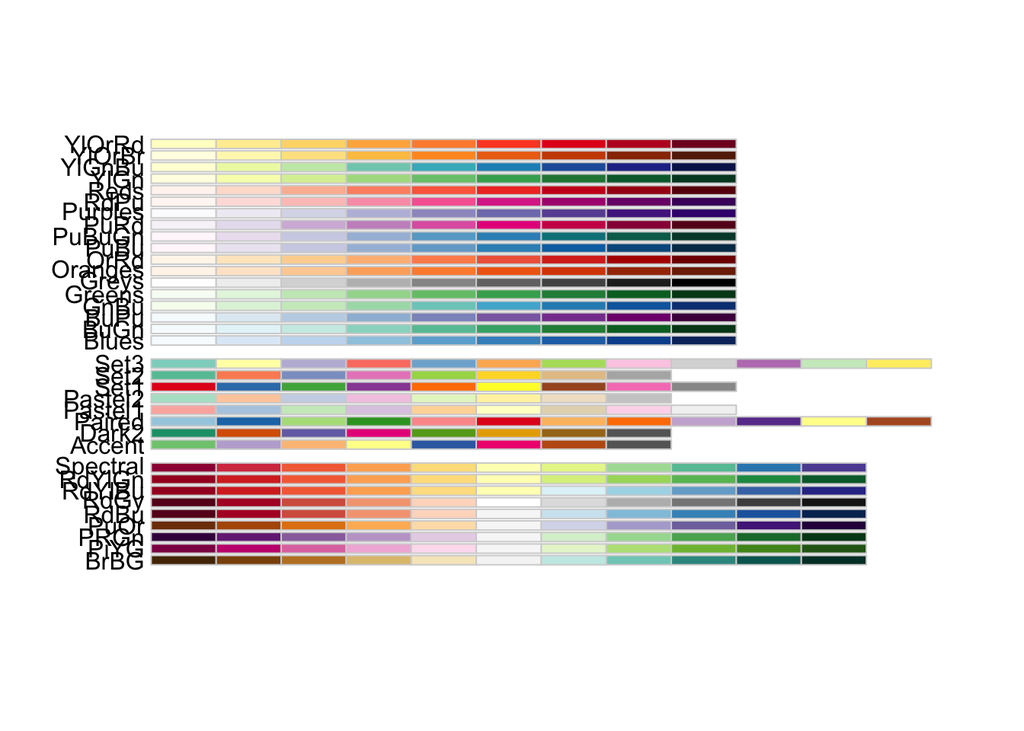

```r
library(ggplot2)
library(RColorBrewer)
display.brewer.all()
```

Demographics: It seems more males involved than females.

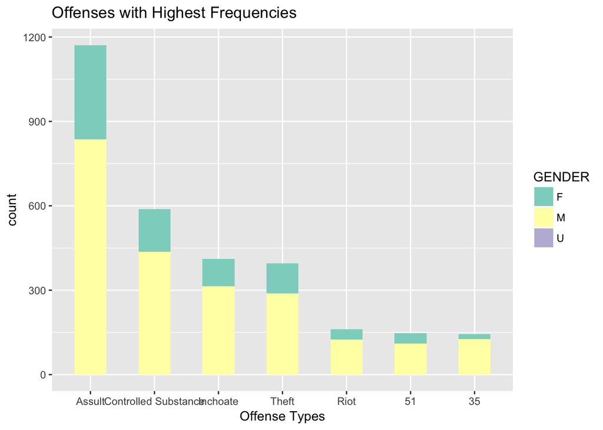

```r
g1<-ggplot(minidat, aes(x=reorder(ShortCode, -table(ShortCode)[ShortCode]),fill=GENDER))+
  geom_bar(width=.5)+
  ggtitle("Offenses with Highest Frequencies")+xlab("Offense Types")+
  scale_fill_brewer(palette="Set3")
g1
```

it seems more males involved than females.

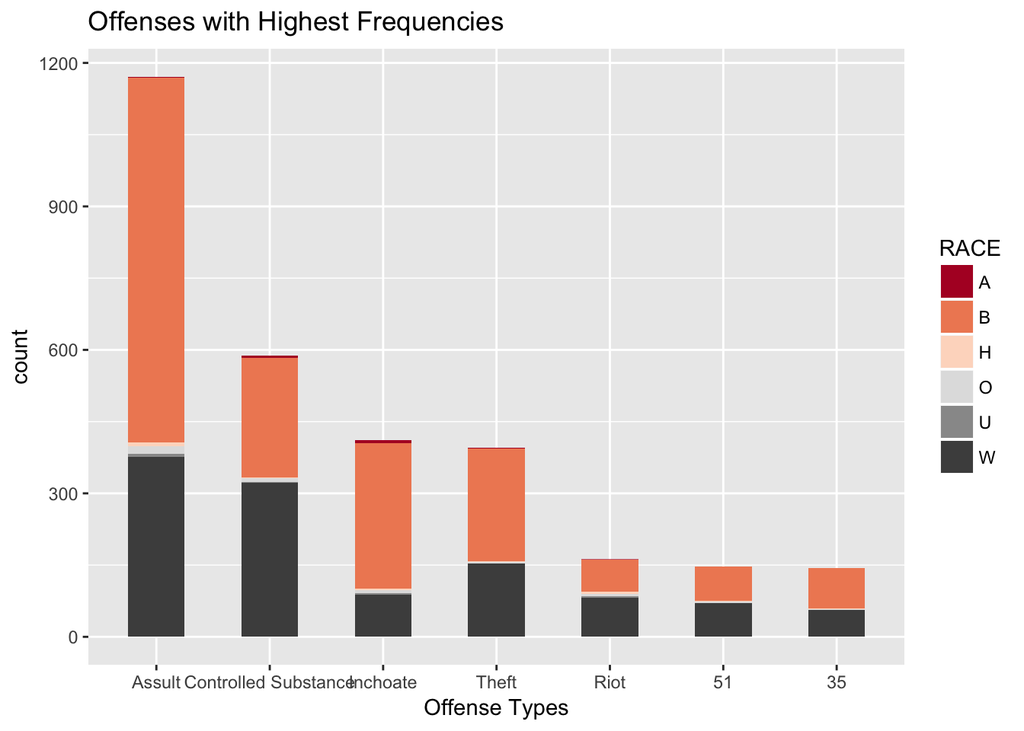

```r
g2<-ggplot(minidat, aes(x=reorder(ShortCode, -table(ShortCode)[ShortCode]),fill=RACE))+
  geom_bar(width=.5)+
  ggtitle("Offenses with Highest Frequencies")+xlab("Offense Types")+
  scale_fill_brewer(palette="RdGy")
g2
```

# MAP

Load the libraries

```r
library(leaflet)
library(sp)
library(rgdal)
```

Select some variables and save the dataframe to DF

```r
DF <- data.frame(lat = minidat$Y, lon = minidat$X, type = minidat$ShortCode)
```

# Set the basic map

```r
map<-leaflet() %>%
  addProviderTiles(providers$CartoDB.Positron,group="Defult")%>%
  addCircleMarkers(lat=subset(DF,type=='Assult')$lat,
                   lng=subset(DF,type=='Assult')$lon,
    radius = 6,
    color = "orange",
    stroke = FALSE, fillOpacity = 0.5,
    group = "Assult")%>%
  addCircleMarkers(lat=subset(DF,type=='Controlled Substance')$lat,
                   lng=subset(DF,type=='Controlled Substance')$lon,
                   radius = 6,
                   color = "green",
                   stroke = FALSE, fillOpacity = 0.5,group="Controlled Substance")%>%
  addCircleMarkers(lat=subset(DF,type=='Inchoate')$lat,
                   lng=subset(DF,type=='Inchoate')$lon,
                   radius = 6,
                   color = "red",
                   stroke = FALSE, fillOpacity = 0.2,group="Inchoate")%>%
  addCircleMarkers(lat=subset(DF,type=='Theft')$lat,
                   lng=subset(DF,type=='Theft')$lon,
                   radius = 6,
                   color = "blue",
                   stroke = FALSE, fillOpacity = 0.2,group="Theft")%>%
  addCircleMarkers(lat=subset(DF,type=='Riot')$lat,
                   lng=subset(DF,type=='Riot')$lon,
                   radius = 6,
                   color = "gray",
                   stroke = FALSE, fillOpacity = 0.5,group="Riot")%>%
  addLayersControl(
    baseGroups = c("Defult"),
    overlayGroups = c("Controlled Substance","Theft","Assult","Riot","Inchoate"),
    options = layersControlOptions(collapsed = FALSE)
  )

map
```

[interactive chart not shown]